# Tutorial 8: Data Mining Basics

Due by 1 April 2022, 8:00 AM

## Submission Instructions

- Select `output: html_document`.
- Include all code chunks, so include `echo=TRUE` in all chunks.
- Replace the placeholder text, “Type your answer here.”, with your own.
- Submit *only* the required question for grading (Part 2: Submission). You can delete everything else for that submission. Remember to include any `library('package_name')` statements that you’ll need to run your code and future reproduction.
- Rename your R Markdown file `T[X]_[MatricNumber].rmd`, and the output will automatically be `T[X]_[MatricNumber].html`.
- Submit your both R Markdown file (.rmd) and HTML (.html) to Luminus for tutorial assignments (upload to Luminus under the correct Submission Folder). We shall do the same for practical exam.
- **It is important to be able to code and produce your Rmarkdown output file *independently*.** You are responsible for de-bugging and programming in the practical exam.

```r
# load required packages
library(dplyr)
library(tidyr)
library(car) # for linearHypothesis()
library(ggplot2) # optional. we expect you to know base graphics, but allow ggplot if you find it easier
library(psych) # for pairs.panels()
library(factoextra) # for fviz_cluster()
library(wooldridge)
library(caret)
```

## Part Two: Assignment Submission

### Question 2 (total 15 points)

- Dataset required: `attend` (wooldridge)

In this question, we will be doing a model selection, principal component analysis, building a simple logit classifier, and finally assessing the output of that classifier for class performance.

The dataset for this question is available at: https://rdrr.io/cran/wooldridge/man/attend.html. a public available dataset about class attendance and final/GPA performance. Again, you need to install and load package `wooldridge` to conveniently load the data into your R workplace.

```r
data('attend')
```

Here are the variables in the dataset:

- `attend`: classes attended out of 32.
- `termGPA`: GPA for current term.
- `priGPA`: cumulative GPA prior to current term.
- `ACT`: ACT score.
- `final`: final test score.
- `atndrte`: percentage of class attendance, i.e. `attend` divided by `32`.
- `hwrte`: percentage of homework turned in.
- `frosh`: freshme if = 1.
- `soph`: sophomore if = 1.
- `missed`: number of classess missed, i.e. `attend` + `missed` = 32.
- `stndfnl`: standardized final test score, i.e. (`final`-mean)/sd.

In the code below I make a new variable `pass` (pass the exam) which is one if student’s final performance belongs to upper 40% of class comparable to his/her peers (curved) based on the standardized final test score, i.e. `stndfnl` is greater than 60th-quantile of `stndfnl`, This would be a binary dependent variable we shall use.

In this question, we will be interested in using the independent variables (student’s class attendance) to classify the sample into whether student will pass or not.

Here are what the independent variables look like (using the `pairs.panels()` function from the `psych` package)

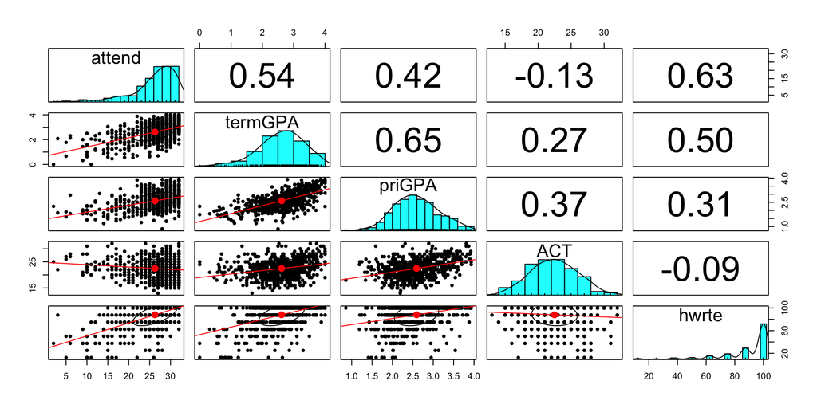

```r
# create a binary variable 'pass',
attend$pass = ifelse(attend$stndfnl > quantile(attend$stndfnl, 0.6), 1, 0)
# removing NA's in the data, just to avoid some programming issues later. WARNING: don't simply do this in your future projects.
attend = attend[complete.cases(attend),]
# Selecting out the independent variables "X".
attendX = attend %>% select(c("attend", "termGPA", "priGPA", "ACT", "hwrte"))
psych::pairs.panels(attendX, lm=TRUE)
```

(Q2a) Let’s first start with our “kitchen sink” regression model `stndfnl ~ attend + termGPA + priGPA + ACT + hwrte + frosh + soph` with entire data set `attend`. (1) using `linearHypothesis()` to jointly test if `termGPA = priGPA = ACT = 0`, i.e. current and previous GPA/test scores do not affect the final test score, and draw your conclusion for the test; (2) run a automated backward model selection using `step()` function and interpret the coefficient of `attend`. (4 points)

From the `linearHypothesis()` test, F-statistic of 100.79 is large, and p-value of smaller than 2.2e-16 is small. These show strong evidence that we can reject the null hypothesis, i.e., the unrestricted model (with “termGPA”, “priGPA” and “ACT”) is not significantly better than restricted model (without “termGPA”, “priGPA” and “ACT”), in terms of their explanatory power. Therefore, including “termGPA”, “priGPA” and “ACT” indeed improves the explanatory power of the model to predict the dependent variable stndfnl, the standardised final test score.

The coefficient before `attend` is -0.02003. This suggests that on average, if one more class out of the total 32 is attended, the standardised final test score will decrease by 0.02003, holding all other variables constant. This is statitically significant since the ending condition of backward stepwise model selection is all remaining predictors have p-values less than 0.05 in their partial F-tests. Thus this predictor has p-value less than 0.05, suggesting that it is statistically significant.

```r
# type your code here
#model1
model1_raw = stndfnl ~ attend + termGPA + priGPA + ACT + hwrte + frosh + soph
model1 = lm(model1_raw, data=attend)

#using linearhypothesis to jointly test the hypotheses
linearHypothesis(model = model1, c("termGPA = 0", "priGPA = 0", "ACT = 0"))
```

```
## Linear hypothesis test
##
## Hypothesis:
## termGPA = 0
## priGPA = 0
## ACT = 0
##
## Model 1: restricted model
## Model 2: stndfnl ~ attend + termGPA + priGPA + ACT + hwrte + frosh + soph
##
##   Res.Df    RSS Df Sum of Sq      F    Pr(>F)
## 1    669 638.97
## 2    666 439.46  3    199.51 100.79 < 2.2e-16 ***
## ---
## Signif. codes:  0 '***' 0.001 '**' 0.01 '*' 0.05 '.' 0.1 ' ' 1
```

```r
#an automated backward model selection
step(model1,
     direction="backward")
```

```
## Start:  AIC=-272.26
## stndfnl ~ attend + termGPA + priGPA + ACT + hwrte + frosh + soph
##
##           Df Sum of Sq    RSS     AIC
## - priGPA   1     0.007 439.47 -274.25
## - frosh    1     1.091 440.55 -272.59
## - hwrte    1     1.179 440.64 -272.45
## <none>                 439.46 -272.26
## - attend   1     1.894 441.36 -271.36
## - soph     1     2.867 442.33 -269.88
## - ACT      1    19.449 458.91 -245.07
## - termGPA  1    83.717 523.18 -156.73
##
## Step:  AIC=-274.25
## stndfnl ~ attend + termGPA + ACT + hwrte + frosh + soph
##
##           Df Sum of Sq    RSS     AIC
## - frosh    1     1.104 440.57 -274.56
## - hwrte    1     1.173 440.64 -274.45
## <none>                 439.47 -274.25
## - attend   1     2.083 441.55 -273.06
## - soph     1     2.879 442.35 -271.85
## - ACT      1    20.973 460.44 -244.82
## - termGPA  1   104.720 544.19 -132.19
##
## Step:  AIC=-274.55
## stndfnl ~ attend + termGPA + ACT + hwrte + soph
##
##           Df Sum of Sq    RSS     AIC
## - hwrte    1     1.058 441.63 -274.94
## <none>                 440.57 -274.56
## - soph     1     1.775 442.35 -273.85
## - attend   1     2.259 442.83 -273.11
## - ACT      1    21.919 462.49 -243.83
## - termGPA  1   105.669 546.24 -131.65
##
## Step:  AIC=-274.94
## stndfnl ~ attend + termGPA + ACT + soph
##
##           Df Sum of Sq    RSS     AIC
## <none>                 441.63 -274.94
## - soph     1     1.997 443.63 -273.90
## - attend   1     4.704 446.33 -269.80
## - ACT      1    23.636 465.27 -241.80
## - termGPA  1   108.245 549.87 -129.19
```

```
##
## Call:
## lm(formula = stndfnl ~ attend + termGPA + ACT + soph, data = attend)
##
## Coefficients:
## (Intercept)       attend      termGPA          ACT         soph
##    -2.61479     -0.02003      0.72305      0.05984     -0.11153
```

Q2b) From the correlation matrix at the very beginning, we can see that many of the independent variables are highly correlated with each other. Let’s try to summarize the data using principal component analysis (PCA).

- Use the `prcomp` function to conduct a PCA. (We’ll have to feed `attendX`, not `attend`, into `prcomp`)
- What is the cumulative proportion of variance explained by the first four PCs?
- Extract the first four PCs and pass them to `attend`. We’ll be using these as predictors.

(3 points)

By using `<pca_object>$rotation[,1:3]`, you can see the loadings on the first 3 PCs. We will not be attempting to interpret the PCs in this question because it’s generally hard to come up with a meaningful interpretation over principal components which are just indices. The only thing to be pointed out, is that PC1 is **negatively** correlated with **every** single variable (to verify if you did it right). Now, Principal Components are just vectors in some high-dimensional space, and so actually it doesn’t make sense to tell whether it’s a vector pointing right or pointing left, it’s just how it is pointing relative to all the other variables. So we can guess, not being trained as an education professional, is that PC1 roughly captures the characteristics of a “lazy” student. (We can thus immediately make a prediction as to the sign of the coefficient if we used PC1 to predict final test score, even before we run Q2c below… Try to guess!)

But in general I would recommend that if you do end up using PCA for your future works, to at least attempt to interpret the PCs, in the spirit of understanding more about the data.

The cumulative proportion of variance explained by the first four PCs is 0.5124 + 0.2641 + 0.09707 + 0.06666 = 0.94023.

```r
# type your code here
#conduct a PCA
pca_1=prcomp(formula = ~ ., data=attendX,center=TRUE,scale=TRUE)
summary(pca_1)
```

```
## Importance of components:
##                           PC1    PC2     PC3     PC4     PC5
## Standard deviation     1.6006 1.1491 0.69665 0.57731 0.54701
## Proportion of Variance 0.5124 0.2641 0.09707 0.06666 0.05984
## Cumulative Proportion  0.5124 0.7764 0.87350 0.94016 1.00000
```

```r
#see the loadings on the first 3 PCs
pca_1$rotation[,1:3]
```

```
##                PC1        PC2         PC3
## attend  -0.4894187  0.3655846  0.13026292
## termGPA -0.5442744 -0.1439334  0.08088831
## priGPA  -0.4831642 -0.3391988  0.54319195
## ACT     -0.1412554 -0.7684402 -0.50934291
## hwrte   -0.4591666  0.3742659 -0.64961600
```

```r
#extract the first four PCs and pass them to attend
attend$pc1=pca_1$x[,"PC1"]
attend$pc2=pca_1$x[,"PC2"]
attend$pc3=pca_1$x[,"PC3"]
attend$pc4=pca_1$x[,"PC4"]
```

Q2c)

Run a logistic regression of `pass` on the top four principal components. Which coefficients are statistically significant?

Using a model with all four PCs, use `predict(<glm_object>, type='response')` to ask the model to predict the probability of pass. Let’s make our rule to define the predicted value of `pass`: being equal to one (predicted “pass”) if the predicted probability is >= 0.60; and zero otherwise (predicted “fail”). Pass the binary predictions to a variable named `pred_pass` in `attend`. How many “Yes” and “No” predictions did the model make? (4 points)

As interpreted from the logistic regression on the top four principal components, the coefficients of intercept, pc1 and pc2 are statistically significant, with p-values of 7.01e-14, 2.32e-15, and 1.37e-10 respectively. All their p-values are small and less than 0.05, suggesting that these coefficients are statistically significant.

106 “Yes”’s (predicted “pass”) are made. 568 “No”’s (predicted “fail”) are made.

```r
# type your code here
#build a model with top four principal components
model2 = glm(pass ~ pc1 + pc2 + pc3 + pc4, data=attend, family = binomial, control = list(maxit = 50))
summary(model2)
```

```
##
## Call:
## glm(formula = pass ~ pc1 + pc2 + pc3 + pc4, family = binomial,
##     data = attend, control = list(maxit = 50))
##
## Deviance Residuals:
##     Min       1Q   Median       3Q      Max
## -1.8222  -0.8792  -0.5800   0.9644   2.3056
##
## Coefficients:
##             Estimate Std. Error z value Pr(>|z|)
## (Intercept) -0.67886    0.09066  -7.488 7.01e-14 ***
## pc1         -0.50512    0.06376  -7.923 2.32e-15 ***
## pc2         -0.52756    0.08218  -6.419 1.37e-10 ***
## pc3         -0.03803    0.12990  -0.293   0.7697
## pc4          0.26283    0.15625   1.682   0.0925 .
## ---
## Signif. codes:  0 '***' 0.001 '**' 0.01 '*' 0.05 '.' 0.1 ' ' 1
##
## (Dispersion parameter for binomial family taken to be 1)
##
##     Null deviance: 882.36  on 673  degrees of freedom
## Residual deviance: 754.82  on 669  degrees of freedom
## AIC: 764.82
##
## Number of Fisher Scoring iterations: 4
```

```r
#predict the probability of pass
new_raw=predict(model2, type="response")

#set up new variable pred_pass in attend
attend$pred_pass=ifelse(new_raw>=0.60, 1, 0)

str(attend)
```

```
## 'data.frame':    674 obs. of  17 variables:
##  $ attend   : int  27 22 30 31 32 29 30 26 24 29 ...
##  $ termGPA  : num  3.19 2.73 3 2.04 3.68 ...
##  $ priGPA   : num  2.64 3.52 2.46 2.61 3.32 ...
##  $ ACT      : int  23 25 24 20 23 26 21 22 24 21 ...
##  $ final    : int  28 26 30 27 34 25 10 34 26 26 ...
##  $ atndrte  : num  84.4 68.8 93.8 96.9 100 ...
##  $ hwrte    : num  100 87.5 87.5 100 100 100 75 100 100 100 ...
##  $ frosh    : int  0 0 0 0 0 0 1 0 1 0 ...
##  $ soph     : int  1 0 0 1 1 1 0 1 0 1 ...
##  $ missed   : int  5 10 2 1 0 3 2 6 8 3 ...
##  $ stndfnl  : num  0.4727 0.0525 0.8929 0.2626 1.7332 ...
##  $ pass     : num  1 0 1 0 1 0 0 1 0 0 ...
##  $ pc1      : num  -0.852 -0.608 -0.57 -0.211 -2.287 ...
##  $ pc2      : num  0.0251 -1.4627 -0.0806 1.2111 -0.1501 ...
##  $ pc3      : num  -0.3538 0.4793 -0.2057 0.0253 0.5034 ...
##  $ pc4      : num  0.398 0.548 -0.448 -0.642 0.11 ...
##  $ pred_pass: num  0 1 0 0 1 0 0 0 0 0 ...
##  - attr(*, "time.stamp")= chr "25 Jun 2011 23:03"
```

```r
#look up how many yes and no predictions the model made
yes <- attend[attend$pred_pass==1,]
nrow(yes)
```

```
## [1] 106
```

```r
no <- attend[attend$pred_pass==0,]
nrow(no)
```

```
## [1] 568
```

Q2d) Finally, let’s manually construct a classification matrix using `table()` function in base R rather than `caret::confusionMatrix()`.

Use `table(x1, x2)` with both your model’s “Pass/Fail” predictions and the actual observed `pass` values. I recommend using the same convention in the lecture slides, where we have actual values on the columns and model prediction on the rows. *We say “pass” is defined as positive event.* (4 points)

- How many True Positives are there?
- How many True Negatives are there?
- How many False Positives are there?
- How many False Negatives are there?
- What is the model’s overall classification accuracy?
- What is the model’s sensitivity?
- What is the model’s precision?
- What is the model’s specificity?

81 True Positives

405 True Negatives

25 False Positives

163 False Negatives

The model’s overall classification accuracy is 0.7210682.

The model’s sensitivity is 0.3319672.

The model’s precision is 0.7641509.

The model’s specificity is 0.9418605.

```r
# type your code here
sum(attend$pred_pass==attend$pass)
```

```
## [1] 486
```

```r
#generate table
table1 <- table(attend$pred_pass, attend$pass)
table1
```

```
##
##       0   1
##   0 405 163
##   1  25  81
```

```r
#number of true positives
tp <- table1[2, 2]
tp
```

```
## [1] 81
```

```r
#number of true negatives
tn <- table1[1, 1]
tn
```

```
## [1] 405
```

```r
#number of false positives
fp <- table1[2, 1]
fp
```

```
## [1] 25
```

```r
#number of false negatives
fn <- table1[1, 2]
fn
```

```
## [1] 163
```

```r
#overall classification accuracy
(tp+tn)/(tp+tn+fp+fn)
```

```
## [1] 0.7210682
```

```r
#sensitivity
tp/(tp+fn)
```

```
## [1] 0.3319672
```

```r
#precision
tp/(tp+fp)
```

```
## [1] 0.7641509
```

```r
#specificity
tn/(fp+tn)
```

```
## [1] 0.9418605
```